# CNN - Cat dog classification - Training & Graph

```python
import pickle
```

```python
X=pickle.load(open('X.pkl','rb'))
y=pickle.load(open('y.pkl','rb'))
```

So, lets do feature scaling just to make calculation faster, lesser the value faster will be calculation

```python
X=X/255
```

```python
X.shape  # lets check shape
```

```
(2000, 100, 100)
```

This saying we have 2000 images, and eaxch image of 100 height and width

Now lets understand some convolutional process:

Here are the three elements that enter into the convolution operation:

1. Input image
2. Feature detector
3. Feature map

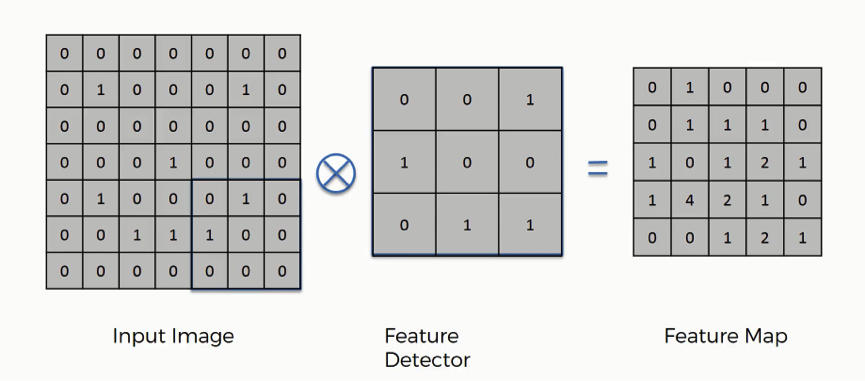

Hows above Feature map working?

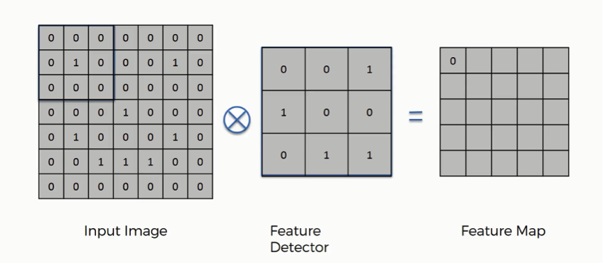

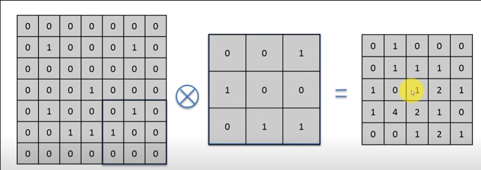

```python
(0*0+0*0+1*0)+(1*0+0*1+0*0)+(0*0+1*0+1*0)
```

```
0
```

So that 0 is going in first cell of 5*5 matrix, so whats happening, 7*7 matrix (Input image) is in convolation with 3*3 kernel and producing output by deducting some matrix.

But above feature detector and input is simple one but in real scenario, suppose our input image is cat, one feature dector will detect cat, one may detect cat nose, in this way it will have multiple output (Feature map)

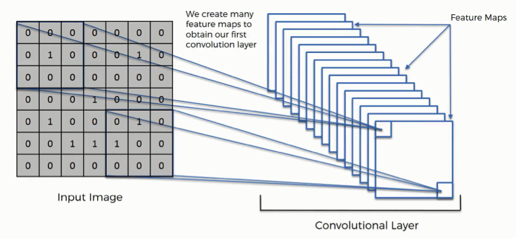

Now lets get back to practical first, again we will move to theory later

```python
from tensorflow.keras.models import Sequential
from tensorflow.keras.layers import Conv2D, MaxPooling2D, Flatten, Dense
import numpy as np

# Assuming X is your input data (a 3D tensor)
X_expanded = np.expand_dims(X, axis=-1)

model = Sequential()

model.add(Conv2D(64, (3,3), activation='relu', input_shape=X_expanded.shape[1:]))
model.add(MaxPooling2D((2,2)))
model.add(Conv2D(64, (3,3), activation='relu'))
model.add(MaxPooling2D((2,2)))
model.add(Flatten())
model.add(Dense(128, activation='relu'))
model.add(Dense(2, activation='softmax'))
```

```python
model.compile(optimizer='adam',
              loss='sparse_categorical_crossentropy',
              metrics=['accuracy'])
```

```python
history=model.fit(X, y, epochs=5, validation_split=0.1)
```

[output not shown]

Now lets see in graph, training and validation accuracy

```python
import matplotlib.pyplot as plt
```

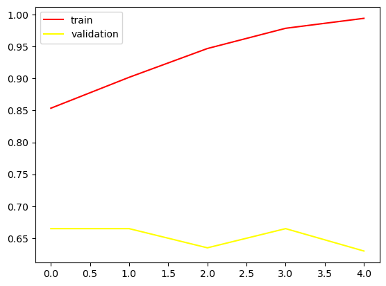

```python
plt.plot(history.history['accuracy'], color='red',label='train')
plt.plot(history.history['val_accuracy'], color='yellow',label='validation')
plt.legend()
```

Here there is a huge gap in model. we can see huge gap in train and validation.So, there is overfitting in model

So now what are some of steps to reduce overfitting- means in training data model is performing very well but not in testing data:

So to reduce overfitting:

- Add more data if we have
- Data Augmentation
- L1/L2 Regulizer
- Dropout
- Batch Norm
- Reduce complexity

So, for now lets do not use this Notebook because we can know later by comparing the difference, but in real industry scenario, we can make changes in same code.